# Estimación funcional de la evaporación de regiones hidrográficas de Brasil

Dr. Jaime Lincovil C.

2022-03-07

**Resumen**. En este trabajo presentamos evidencia de la gran ventaja del uso de ondaletas (*wavelets*) en la estimación funcional. Comparamos su desempeño con un método clásico de *spline*. Utilizamos los datos de evapotranspiración de 12 regiones hidrográficas de Brasil. Los datos presentan un comportamiento de estacional y un alto nivel de ruido. Para la comparación de las estimaciones empleamos la media total de evapotranspiración de la región del Atlántico Este. Concluimos que la cura estimada vía ondaletas se adapta mejor a la evolución de los datos que la curva estimada vía *spline*.

# Estudio descriptivo

El conjunto de datos contiene series promedio de evapotranspiración en milímetros de regiones hidrográficas en Brasil entre los años 1980 y 2018. Los datos se dividen en 12 grupos (regiones hidrográficas), con 897 observaciones que tienen M=14.245 puntos tomados diariamente. Las regiones consideradas son las siguientes: Amazonía, Tocantins-Araguaia, Atlántico Noreste Oeste, Parnaíba, Atlántico Noreste Este, São Francisco, Atlántico Este, Atlántico Sudeste. La base de datos fue publicada en la plataforma *zenodo* Chagas et al. (2020b) disponible en [https://zenodo.org/record/3709338#.Yh50UHVBzIU]. La base de datos completa fue descrita en el trabajo Chagas et al. (2020a). No encontramos citas de revistas estadísticas.

La Figura 1 muestra series de evapotranspiración en milímetros de regiones hidrográficas coloreadas por grupo. Por razones de la gran cantidad de puntos, se consideraron las primeras 1024 observaciones. Los restantes tuvieron un comportamiento similar debido al comportamiento estacionario de los datos. Observamos un comportamiento estacionario en todos ellos y diferencias en el tiempo cuando ocurren las transiciones de tendencia.

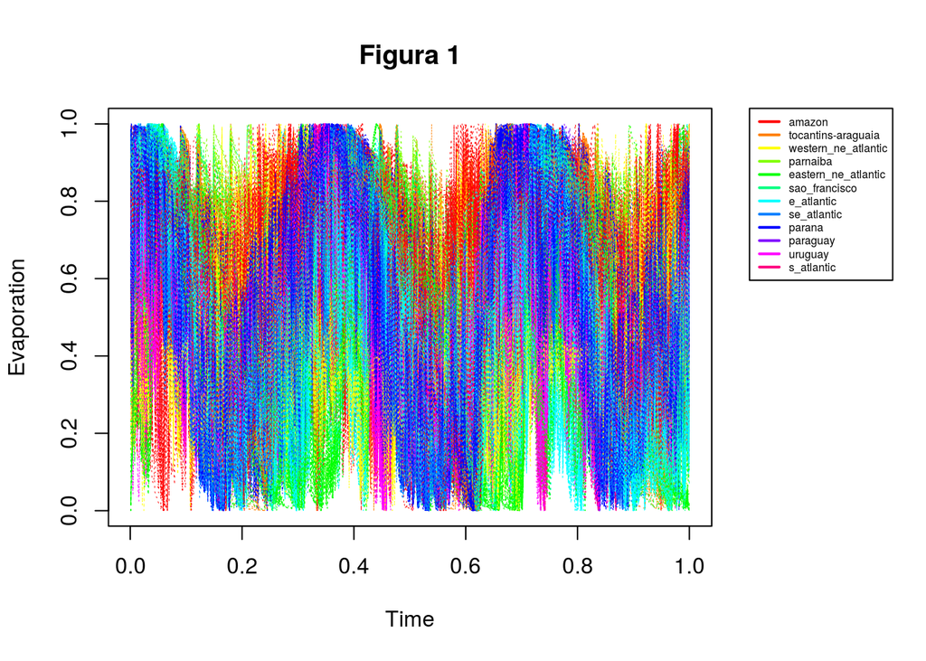

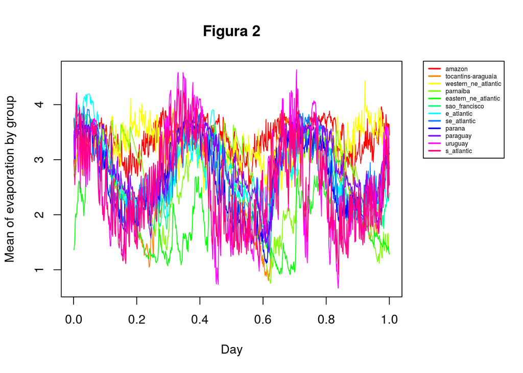

```
## [1] 36.41054 17.85149 36.98006 26.30188 29.69018 39.92257 23.67342 34.26327
```

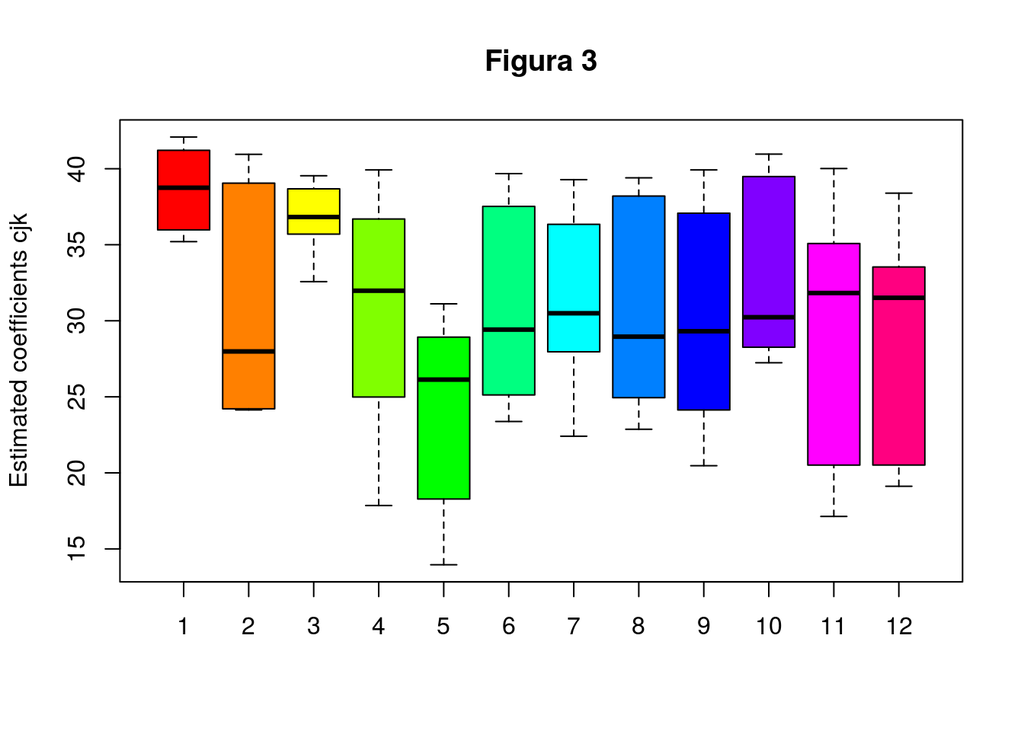

Tabla 1. Variación de djk antes y después del alisamiento.

| 42.285 | 1.123 | 2.655 |
| --- | --- | --- |
| 205.723 | 41.233 | 20.043 |
| 66.155 | 0.000 | 0.000 |
| 167.228 | 65.358 | 39.083 |
| 187.211 | 19.949 | 10.656 |
| 95.845 | 29.668 | 30.954 |
| 82.595 | 1.485 | 1.798 |
| 82.922 | 15.165 | 18.288 |
| 113.187 | 23.726 | 20.962 |
| 91.056 | 43.503 | 47.776 |
| 333.074 | 142.031 | 42.642 |
| 256.689 | 65.342 | 25.456 |

# Reconstrucción de las medias de evaporación

La Figura 4 muestra la evapotranspiración promedio *observada* en la región del **Atlántico** este y en rojo la evapotranspiración promedio *estimada* (primera 1024 observaciones). Mediante la aplicación de la suavización de los coeficientes $d_{jk}$, la estimación se realizó mediante reconstrucción de datos, considerando un nivel inicial igual a 5. Se observó la gran flexibilidad de la estimación para adaptarse a los incrementos y decrementos irregulares de los datos.

Es recomendable utilizar un método estadístico basado en wavelet debido a sus ventajas matemáticas y computacionales expuestas en diferentes trabajos (Morettin, 2017 ; Vidakovic, 2009). Otros metodos basado en bases *spline* (polinomios) y analisis espectral (base sinusoidal) (Ramsay and Silverman, 2002). Sin embargo, los métodos basada en ondaletas destacan devido a que su capacidad de para modelar datos no estacionarios. La estimación via ondaletas es realizda por medio de la reconstrucción de los datos posterior a un alisamiento de los coeficientes $d_{jk}$.

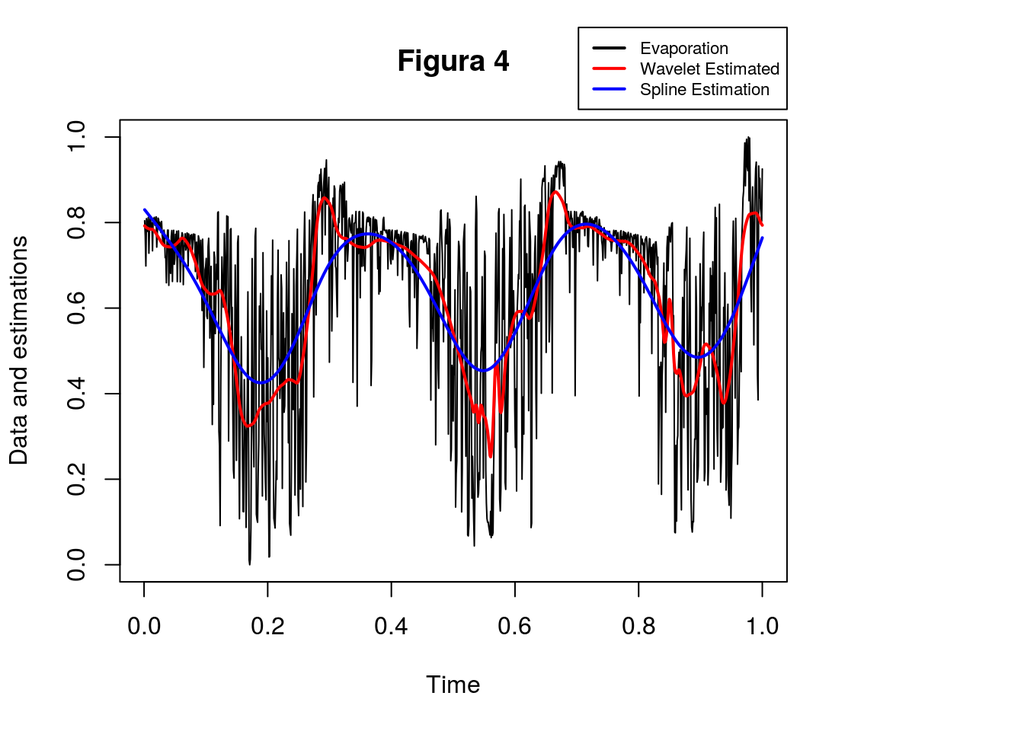

La estimación de la curva de evapotranspiración promedio vía reconstrucción de ondaletas muestra una gran flexibilidad para adaptarse a los cambios de la evapotranspiración. Observamos como ante cambios de aumentos y decrecimo cortos y repentinos, la estimación se adapta muy bien.

# Referencias

- Chagas, V. B. P., Chaffe, P. L. B., Addor, N., Fan, F. M., Fleischmann, A. S., Paiva, R. C. D., and Siqueira, V. A. (2020a). Camels-br: hydrometeorological time series and landscape attributes for 897 catchments in brazil. Earth System Science Data, 12(3): 2075–2096.
- Chagas, V. B. P., Chaffe, P. L. B., Addor, N., Fan, F. M., Fleischmann, A. S., Paiva, R. C. D., and Siqueira, V. A. (2020b). CAMELS-BR: Hydrometeorological time series and landscape attributes for 897 catchments in Brazil - link to files.
- Morettin, P. A., Pinheiro, A., & Vidakovic, B. (2017). Wavelets in functional data analysis. New York, NY: Springer.
- J.O. Ramsay, B.W. Silverman, Functional Data Analysis, 2nd edn. (Springer, New York, 2006).
- Vidakovic, B. (2009). Statistical modeling by wavelets (Vol. 503). John Wiley & Sons.